# Assignment 2

Ilaria Crippa

2024-01-21

#Assignment 2

## Simple linear regression model

### Linear regression model with a single predictor

We open the data and omit the missing values.

```r
data = read.csv("Bias_correction.csv", header = T)
data$Date = as.Date(data$Date, format = "%d/%m/%Y")
station = as.factor(data$station)
data = na.omit(data)
```

Using the method of least squares, we fit a linear regression model with a single predictor. The selected explanatory variable is the next-day average cloud coverage (CC3) in % forecasted between 12:00 and 17:00 by the Local Data Assimilation and Prediction System (LDAPS), a Numerical Weather Prediction model developed by the Korean Meteorological Administration over the city of Seoul. The dependent variable is the observed next-day maximum air temperature (°C). The predictor has been selected because the exploratory analysis of the data revealed the existence of a negative correlation with the next-day maximum air temperature, stronger than that observed with the next-day minimum air temperature.

```r
ols_Tmax <- lm(data$Next_Tmax ~ data$CC3, data=data)
summary(ols_Tmax)
```

```
##
## Call:
## lm(formula = data$Next_Tmax ~ data$CC3, data = data)
##
## Residuals:
##      Min       1Q   Median       3Q      Max
## -11.1619  -1.7302   0.1028   1.8361   8.4458
##
## Coefficients:
##             Estimate Std. Error t value Pr(>|t|)
## (Intercept) 32.31034    0.04925  656.11   <2e-16 ***
## data$CC3    -6.51501    0.12188  -53.45   <2e-16 ***
## ---
## Signif. codes:  0 '***' 0.001 '**' 0.01 '*' 0.05 '.' 0.1 ' ' 1
##
## Residual standard error: 2.652 on 7586 degrees of freedom
## Multiple R-squared:  0.2736, Adjusted R-squared:  0.2735
## F-statistic:  2857 on 1 and 7586 DF,  p-value: < 2.2e-16
```

```r
ols_Tmin <- lm(data$Next_Tmin ~ data$CC3, data=data)
summary(ols_Tmin)
```

```
##
## Call:
## lm(formula = data$Next_Tmin ~ data$CC3, data = data)
##
## Residuals:
##      Min       1Q   Median       3Q      Max
## -11.7325  -1.5890   0.2096   1.6644   6.8908
##
## Coefficients:
##             Estimate Std. Error t value Pr(>|t|)
## (Intercept) 23.08905    0.04602 501.755  < 2e-16 ***
## data$CC3    -0.56126    0.11389  -4.928 8.48e-07 ***
## ---
## Signif. codes:  0 '***' 0.001 '**' 0.01 '*' 0.05 '.' 0.1 ' ' 1
##
## Residual standard error: 2.478 on 7586 degrees of freedom
## Multiple R-squared:  0.003191,   Adjusted R-squared:  0.00306
## F-statistic: 24.28 on 1 and 7586 DF,  p-value: 8.485e-07
```

###Graphs of the data and the fitted line

We can graph the data and the fitted line of the linear regression. As anticipated, we can notice a steeper slope when using the next-day maximum air temperature rather than the next-day minimum air temperature.

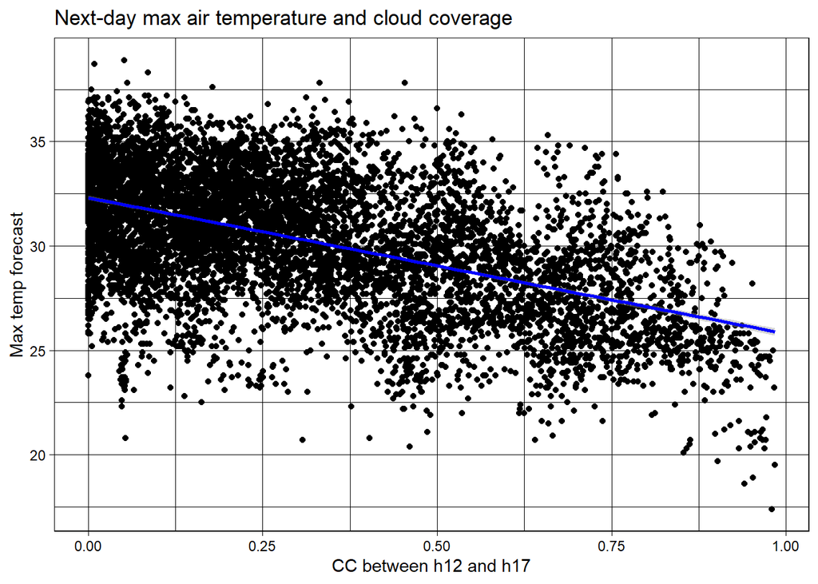

```r
library(ggplot2)
ggplot(data, aes(x = data$CC3, y = data$Next_Tmax)) +
  geom_point() +
  geom_smooth(method="lm", color="blue")+
  theme_linedraw()+
  labs(title = "Next-day max air temperature and cloud coverage",
    x="CC between h12 and h17",
    y="Max temp forecast"
  )
```

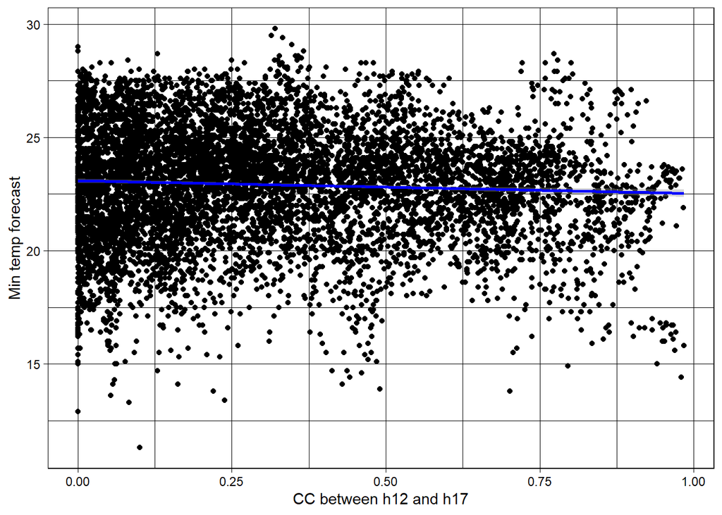

```r
ggplot(data, aes(x = data$CC3, y = data$Next_Tmin)) +
  geom_point() +
  geom_smooth(method="lm", color="blue")+
  theme_linedraw()+
  labs(
    x="CC between h12 and h17",
    y="Min temp forecast"
  )
```

###Interpretation of the estimated parameters and their uncertainties

The estimated intercept (β<sub>0</sub>) represents the value of the next-day maximum temperature when the forecast of the LDAPS model for the next-day cloud coverage is equal to 0%, i.e. when the sky is completely clear. It means that, when the forecast of the next-day average cloud coverage between 12:00 and 17:00 is equal to 0%, the next-day maximum air temperature is predicted to be equal to 32.31°C. The small p-value indicates that the result is significant.

Both the intercept and the coefficient for CC3 have relatively small standard errors (0.049 and 0.122 respectively), indicating relatively precise estimates.

###The coefficient of determination

The coefficient of determination, also denoted as R<sup>2</sup>, represents the the proportion of the variance in the dependent variable that is predictable from the independent variable in a regression model. Its value ranges from 0 to 1, where 0 indicates that the model does not explain any variability, while a value of 1 indicates that the model explains all the variability. The linear regression model constructed with the chosen variables has the following coefficient of determination:

```r
R_squared = summary(ols_Tmax)$r.squared
R_squared
```

```
## [1] 0.2735926
```

It means that the forecast for the next-day average cloud coverage between 12:00 and 17:00 is able to explain 27.36% of the total variability in the next-day maximum air temperature.

If we want to use the model to predict, we first need to assess the estimated variance of the prediction:

```r
sigma = summary(ols_Tmax)$sigma
mean_CC3 = mean(data$CC3)
SSx = sum((data$CC3-mean_CC3)^2)
sigma_pred = sigma * sqrt(1+1/(nrow(data))+(2-mean_CC3)^2/SSx)
sigma_pred
```

```
## [1] 2.660443
```

###Likelihood function

In the maximum likelihood estimation, the likelihood function is a function of the coefficients β<sub>0</sub> and β<sub>1</sub>, conditional on the estimated standard error, and it has its peak at the maximum likelihood estimate. The MLE corresponds to the value of the parameters where the function reaches its highest point.

```r
summary(ols_Tmax)
```

```
##
## Call:
## lm(formula = data$Next_Tmax ~ data$CC3, data = data)
##
## Residuals:
##      Min       1Q   Median       3Q      Max
## -11.1619  -1.7302   0.1028   1.8361   8.4458
##
## Coefficients:
##             Estimate Std. Error t value Pr(>|t|)
## (Intercept) 32.31034    0.04925  656.11   <2e-16 ***
## data$CC3    -6.51501    0.12188  -53.45   <2e-16 ***
## ---
## Signif. codes:  0 '***' 0.001 '**' 0.01 '*' 0.05 '.' 0.1 ' ' 1
##
## Residual standard error: 2.652 on 7586 degrees of freedom
## Multiple R-squared:  0.2736, Adjusted R-squared:  0.2735
## F-statistic:  2857 on 1 and 7586 DF,  p-value: < 2.2e-16
```

```r
coeff = summary(ols_Tmax)$coefficients
coeff
```

```
##              Estimate Std. Error   t value Pr(>|t|)
## (Intercept) 32.310341 0.04924531 656.11003        0
## data$CC3    -6.515008 0.12188395 -53.45255        0
```

```r
beta0 = coeff[1,1]
beta0
```

```
## [1] 32.31034
```

```r
beta1 = coeff[2, 1]
beta1
```

```
## [1] -6.515008
```

```r
sigma = summary(ols_Tmax)$sigma
sigma
```

```
## [1] 2.652354
```

```r
mean_CC3 = mean(data$CC3)
SSx = sum((data$CC3-mean_CC3)^2)
SE_beta0 = coeff[1,2]
SE_beta0
```

```
## [1] 0.04924531
```

```r
SE_beta1 = coeff[2, 2]
SE_beta1
```

```
## [1] 0.121884
```

```r
Cov_betas = -sigma^2 * mean_CC3/SSx
Cov_betas
```

```
## [1] -0.004717368
```

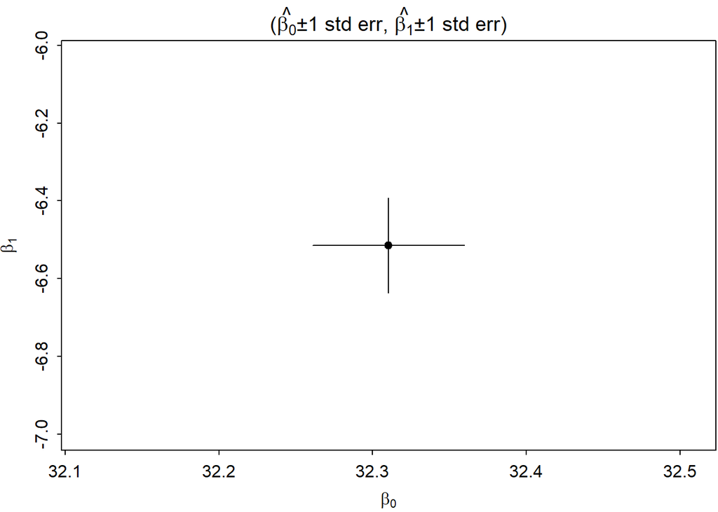

```r
rng.beta0 <- beta0 + SE_beta0*c(-4,4)
rng.beta1 <- beta1 + SE_beta1*c(-4,4)
par(mar=c(3,3,2,0.1), mgp=c(2,0.5,0), tck=-0.01)
plot(beta0, beta1, pch=19, xlim = rng.beta0, ylim = rng.beta1,
xlab=expression(beta[0]), ylab=expression(beta[1]),
main=expression(paste("(", hat(beta[0]), "±1", " std err, ", hat(beta[1]), "±1", " std err)")))
lines(rep(beta0, 2), beta1 + c(-1,1)*SE_beta1)
lines(beta0 + c(-1,1)*SE_beta0, rep(beta1, 2))
```

#####OLS estimates with ±1 standard error bars for each parameter

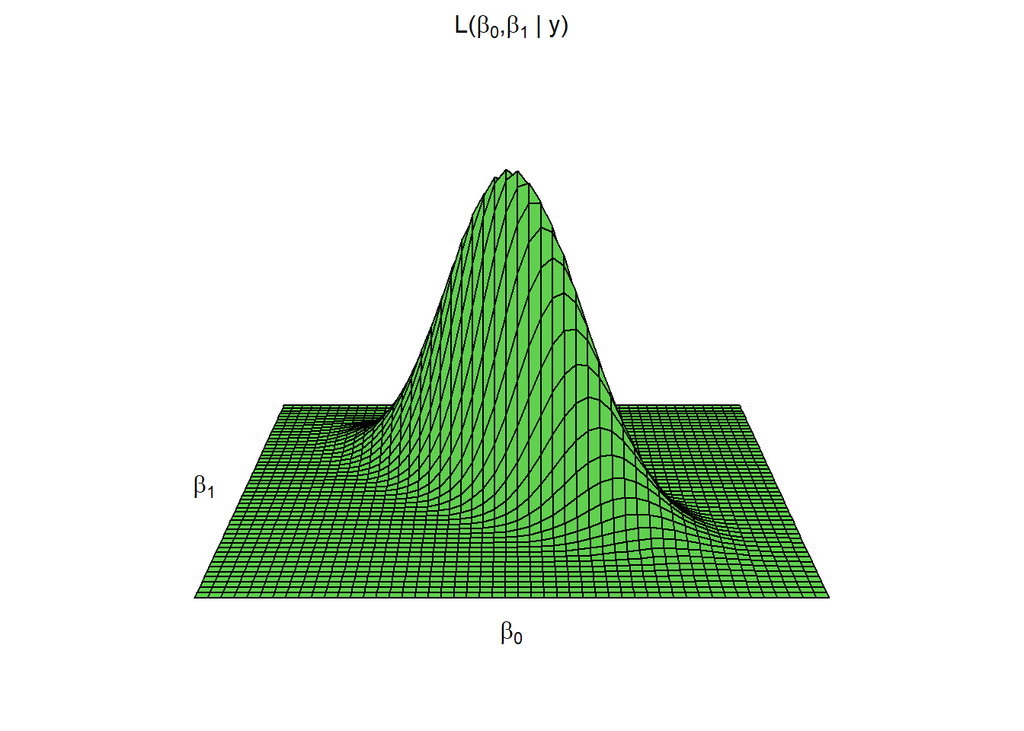

```r
beta0.grid <- seq(rng.beta0[1], rng.beta0[2], length=50)
beta1.grid <- seq(rng.beta1[1], rng.beta1[2], length=50)

loglike = array(NA, c(length(beta0.grid),length(beta1.grid)))
for (i in 1:length(beta0.grid)){
for (j in 1:length(beta1.grid)){
loglike[i,j] = sum(dnorm(data$Next_Tmax,
mean = beta0.grid[i]+beta1.grid[j]*data$CC3,
sd = sigma, log=TRUE))
}
}
max_loglike <- max(loglike, na.rm = TRUE)
loglike <- loglike - max_loglike
like = exp(loglike)

trans3d <- function(x,y,z, pmat) {
tr <- cbind(x,y,z,1) %*% pmat
list(x = tr[,1]/tr[,4], y= tr[,2]/tr[,4])}

par(mar=c(0,0,0,0), mgp=c(2,0.5,0), tck=-0.01, pty='s')

persp(beta0.grid, beta1.grid, like, xlab=expression(beta[0]),ylab='', zlab="likelihood", d=2, box = FALSE, axes=TRUE, expand=.6, col = 3) -> res

text(trans3d(mean(rng.beta0), rng.beta1[1]-.12*(rng.beta1[2]-rng.beta1[1]), 0, pm = res), expression(beta[0]))
text(trans3d(rng.beta0[1]-.08*(rng.beta0[2]-rng.beta0[1]), mean(rng.beta1), 0, pm = res), expression(beta[1]))
mtext(expression(paste("L(",beta[0],",", beta[1]," | y)")), side=3, line=-1.5)
```

#####Likelihood function

###Linear regression model with Bayesian approach assuming weakly informative priors

```r
library(rstanarm)
Bayes <- stan_glm(Next_Tmax ~ CC3, data = data, refresh = 0,
                  prior = normal(0.5, 0.25),
                  prior_intercept = normal(-3.25, 3.25))

print(Bayes)
```

```
## stan_glm
##  family:       gaussian [identity]
##  formula:      Next_Tmax ~ CC3
##  observations: 7588
##  predictors:   2
## ------
##             Median MAD_SD
## (Intercept) 31.9    0.0
## CC3         -5.1    0.1
##
## Auxiliary parameter(s):
##       Median MAD_SD
## sigma 2.7    0.0
##
## ------
## * For help interpreting the printed output see ?print.stanreg
## * For info on the priors used see ?prior_summary.stanreg
```

###Simulations from the linear model

We construct the histograms of the posterior simulations for the intercept, slope and residual Se of the fitted model.

```r
library(rstanarm)
Bayes2 <- stan_glm(Next_Tmax ~ CC3, data = data, refresh = 0)
print(Bayes2)
```

```
## stan_glm
##  family:       gaussian [identity]
##  formula:      Next_Tmax ~ CC3
##  observations: 7588
##  predictors:   2
## ------
##             Median MAD_SD
## (Intercept) 32.3    0.1
## CC3         -6.5    0.1
##
## Auxiliary parameter(s):
##       Median MAD_SD
## sigma 2.7    0.0
##
## ------
## * For help interpreting the printed output see ?print.stanreg
## * For info on the priors used see ?prior_summary.stanreg
```

```r
posterior_interval(Bayes2)
```

```
##                    5%       95%
## (Intercept) 32.227129 32.393952
## CC3         -6.722772 -6.311725
## sigma        2.618458  2.687160
```

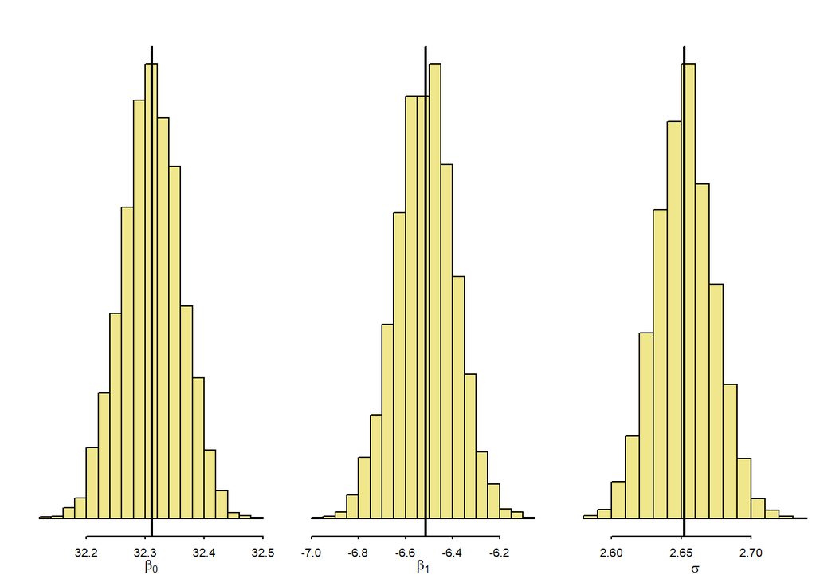

```r
simulations = as.matrix(Bayes2)
n_sims = nrow(simulations)
beta0_sims = simulations[,1]
beta1_sims = simulations[,2]
sigma_sims = simulations[,3]

par(mfrow=c(1,3), mar=c(3,2,3,0), mgp=c(1.5,.5,0), tck=-.01)
hist(beta0_sims, xlab=expression(beta[0]), ylab="", main="",
cex.axis=.9, cex.lab=1.1, yaxt="n", col="khaki")
abline(v=median(beta0_sims), lwd=2)
hist(beta1_sims, xlab=expression(beta[1]), ylab="", main="",
cex.axis=.9, cex.lab=1.1, yaxt="n", col="khaki")
abline(v=median(beta1_sims), lwd=2)
hist(sigma_sims, xlab=expression(sigma), ylab="", main="",
cex.axis=.9, cex.lab=1.1, yaxt="n", col="khaki")
abline(v=median(sigma_sims), lwd=2)
```

Now, we plot the joint posterior distribution of the slope and the intercept. We simulate n = 4000 dots with coordinates β<sub>0</sub> and β<sub>1</sub> and then trace a line *y = β<sub>0</sub> +β<sub>1</sub>x*.

[figure not shown]

```r
par(mfrow=c(1,2),mar=c(3,3,2,.1), mgp=c(1.7,.5,0), tck=-.01)

# posterior simulations of the coefficients
plot(beta0_sims, beta1_sims, xlab=expression(beta[0]), ylab=expression(beta[1]),
main="", bty="l", pch=20, cex=.2)

# posterior draws of the regression line
plot(c(-.7, 4.5), c(43,63), type="n", xaxt="n", yaxt="n", bty="l",
main="", xlab="Forecasted next-day average Cloud Cover, 12:00-17:00",
ylab="Next-day maximum temperature")

axis(1, seq(0,1,0.25), paste(seq(0,1,0.25),sep=""), mgp=c(2,.5,0))
axis(2, seq(25,40,5), paste(seq(25,40,5),"°",sep=""), mgp=c(2,.5,0))
for (i in 1:4000){
  abline(beta0_sims[i], beta1_sims[i], lwd=.5)
}
abline(50, 0, lwd=2, col="gray")
points(data$CC3, data$Next_Tmax, pch=20, cex=1.5, col="red")
```